### A basic comparison of $\texttt{ouch}$ and $\texttt{OUwie}$ using ‘data(tworegime)’

In this document, I will identify the differences between $\texttt{ouch}$ and $\texttt{OUwie}$, focusing especially on differences in how they compute the weight and covariance matrices, as those are key to the fitting procedures of each program. To pick a particular case, I will use the sample data contained in the ‘tworegime’ dataset that is part of $\texttt{OUwie}$. A cursory examination of this dataset makes it clear it is a realistic phylogeny with 64 tips and 63 internal nodes (no polytomies), with a single regime switch occurring between the ancestral black regime and the red regime.

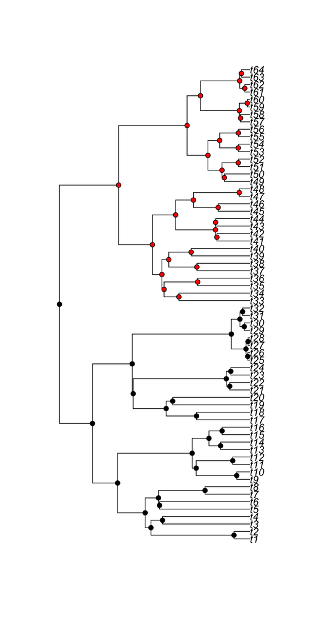

Fig. 1. The ‘tworegime’ phylogeny and regime painting.

An examination of the phenotypic data suggests that the species in the different regimes have different mean phenotypic values.

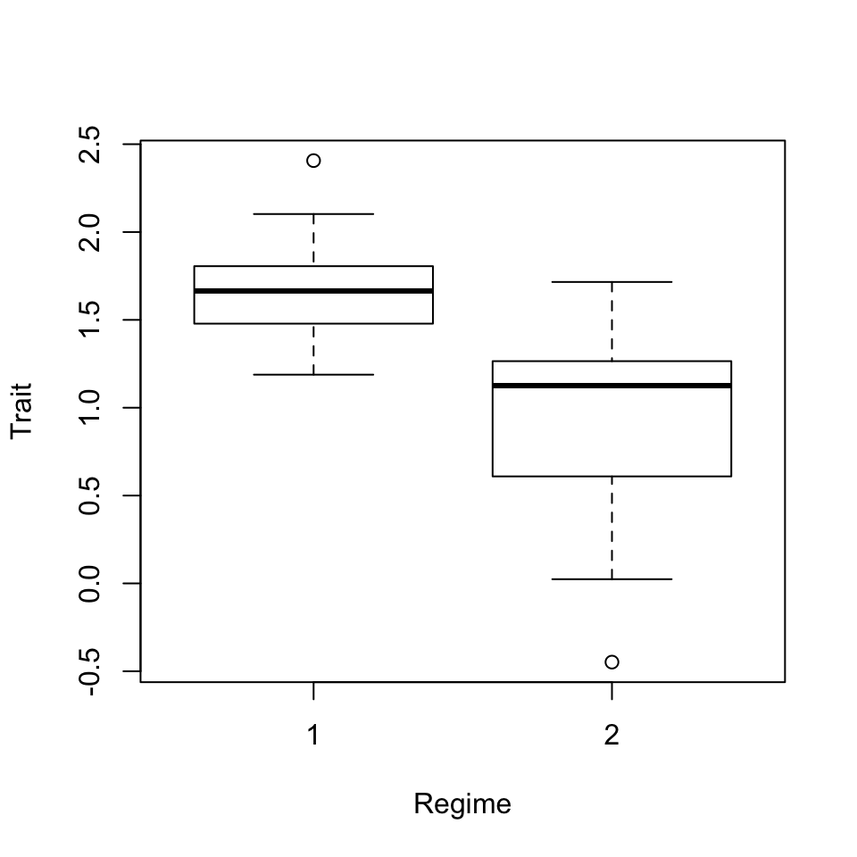

Fig. 2. Phenotypic data for the two regimes.

I will fit this tree and phenotypic data to an Ornstein-Uhlenbeck model with a single value for $\alpha$ and $\sigma$ and separate optima for the two regimes using ‘model=“OUM”’ in a call to the function OUwie() in the $\texttt{OUwie}$ package. Note that I am specifiying the options ‘scaleHeight=TRUE’ and ‘root.station=TRUE’ to make the fitting procedure as close to the one used by $\texttt{ouch}$ as possible, as $\texttt{ouch}$ scales the tree height to be equal to 1 and does not estimate the root state $\theta_0$ but instead draws it from the stationary distribution of the OU process. This produces estimates of $\alpha=1.39$, $\sigma^2=0.65$, $\theta_1=1.68$, and $\theta_2=0.81$.

```r
set.seed(10001)
source("OUwie.R")
source("varcov.ou.R")
source("weight.mat.R")
ouwiefit <- OUwie(tree, trait, model="OUM", scaleHeight=TRUE, root.station=TRUE, quiet=TRUE)
ouwiefit
```

```
##
## Fit
##        lnL      AIC     AICc    BIC model ntax
##  -19.51323 47.02647 47.70443 55.662   OUM   64
##
##
## Rates
##                  1         2
## alpha    1.3917460 1.3917460
## sigma.sq 0.6545677 0.6545677
##
## Optima
##                  1         2
## estimate 1.6751480 0.8109022
## se       0.1822023 0.2267676
##
##
## Half life (another way of reporting alpha)
##         1         2
## 0.4980414 0.4980414
##
## Arrived at a reliable solution
```

To fit an OU model to this data using $\texttt{ouch}$, I first need to convert the tree from ‘phylo’ format to ‘ouchtree’ format and then ‘paint’ the tree with the regime painting. There is a little ambiguity about this painting, specifically on the regime for the branch descending from the root to the clade containing species t33 to t64. Thus I will compare the two different regime paintings, shown below.

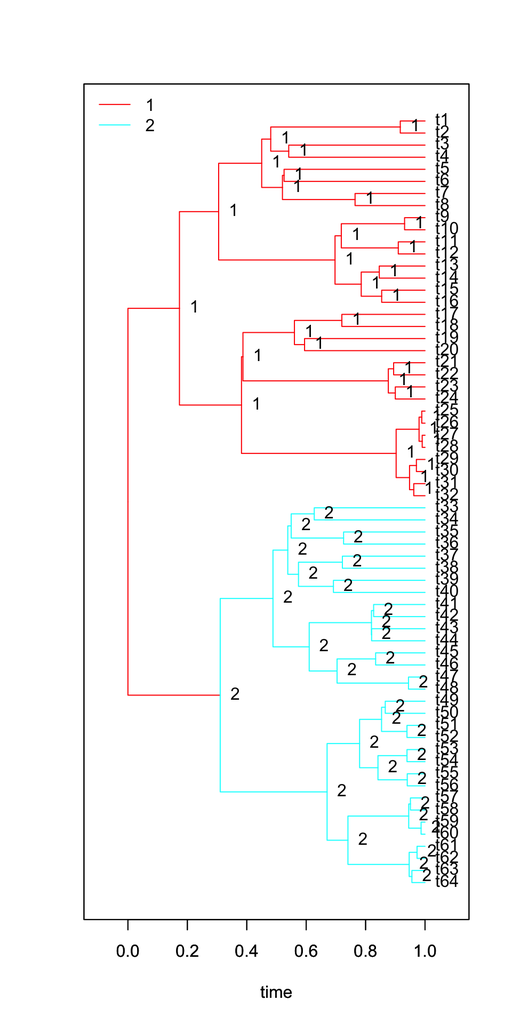

Fig. 3. One possible regime painting for the $\texttt{ouch}$ version of the phylogenetic tree and regime painting.

```r
ouch.tree <- ape2ouch(tree)
regime1 <- paint(ouch.tree, subtree=c('1'=1,'32'=2), branch=c('1'=1))
regime2 <- paint(ouch.tree, subtree=c('1'=1,'32'=2), branch=c('1'=1,"32"=2))
plot(ouch.tree, regimes=regime1)
```

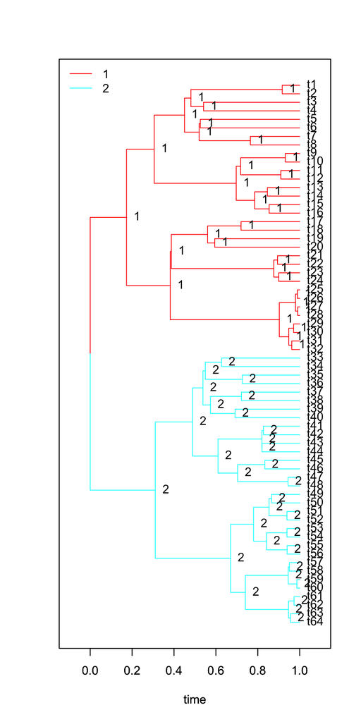

Fig. 4. The other possible regime painting for the $\texttt{ouch}$ version of the phylogenetic tree and regime painting.

```r
plot(ouch.tree, regimes=regime2)
```

I can now use $\texttt{ouch}$ to fit the phenotypic data and compare these fits to those obtained by $\texttt{OUwie}$. You can see that they converge on different values for selection strength ($\alpha$), drift intensity ($\sigma^2$), and the optima ($\theta_1$ and $\theta_2$). You can also see that the different regime paintings in $\texttt{ouch}$ produce different estimates of the selective optima, but agree on the estimates of selection strength and drift intensity.

```r
ouch.trait <- rep(NA, ouch.tree@nnodes)
## match tips of the ouchtree with tips of the OUwie tree
ouch.trait[sapply(as.character(trait$Genus_species), function(n) which(ouch.tree@nodelabels==n))] <- trait$X
names(ouch.trait) <- ouch.tree@nodes
## fit the ouch model
ouchfit1 <- hansen(ouch.trait, tree=ouch.tree, regimes=regime1, sqrt.alpha=1, sigma=1)
ouchfit2 <- hansen(ouch.trait, tree=ouch.tree, regimes=regime2, sqrt.alpha=1, sigma=1)
## comparing ouch and OUwie fits for selection strength
fits <- data.frame(
  alpha=c(ouwiefit$solution["alpha",1], summary(ouchfit1)$alpha, summary(ouchfit2)$alpha),
  sigma.sq=c(ouwiefit$solution["sigma.sq",1], summary(ouchfit1)$sigma.sq, summary(ouchfit2)$sigma.sq),
  theta1=c(ouwiefit$theta[1,1], summary(ouchfit1)$optima$ouch.trait[1], summary(ouchfit2)$optima$ouch.trait[1]),
  theta2=c(ouwiefit$theta[2,1], summary(ouchfit1)$optima$ouch.trait[2], summary(ouchfit2)$optima$ouch.trait[2])
)
rownames(fits) <- c("OUwie", "ouch1", "ouch2")
fits
```

```
##          alpha  sigma.sq   theta1    theta2
## OUwie 1.391746 0.6545677 1.675148 0.8109022
## ouch1 1.593695 0.6913296 1.676267 0.3937266
## ouch2 1.593695 0.6913296 1.676267 0.6032099
```

Moreover, if you calculate the likelihood of the $\texttt{OUwie}$ parameter estimates using the $\texttt{ouch}$ methods, you get different likelihoods and different estimates of the selective optima. (Note that I will work with the $\texttt{ouch}$ regime painting ‘regime1’ for this calculation.)

```r
## Likelihoods
summary(hansen(ouch.trait, tree=ouch.tree, regimes=regime1, sqrt.alpha=sqrt(ouwiefit$solution["alpha",1]), sigma=sqrt(ouwiefit$solution["sigma.sq",1]), fit=FALSE))$loglik
```

```
## [1] -19.78729
```

```r
ouwiefit$loglik
```

```
## [1] -19.51323
```

```r
## Optima
summary(hansen(ouch.trait, tree=ouch.tree, regimes=regime1, sqrt.alpha=sqrt(ouwiefit$solution["alpha",1]), sigma=sqrt(ouwiefit$solution["sigma.sq",1]), fit=FALSE))$optima$ouch.trait
```

```
##         1         2
## 1.6751335 0.2936357
```

```r
ouwiefit$theta[,1]
```

```
## [1] 1.6751480 0.8109022
```

### Comparing the calculation of the covariance matrices

All of this points to differences in how the two methods are estimating the covariance and weight matrices (equations A5 and A7 of Butler and King (2004)). Importantly, the covariance matrix calculation in $\texttt{ouch}$ is slightly modified from equation A5 based on Ho and Ane (2013). Equation (A5) in Butler and King calculates the variance between two tips $i$ and $j$ that diverged at time $s_{ij}$ as
$$\begin{equation}
V_{ij} = \frac{\sigma^2}{2\alpha} e^{-2\alpha(T-s_{ij})}\left(1-e^{-2\alpha s_{ij}}\right)
\end{equation}$$
Thus, the variance, given the $\texttt{OUwie}$ estimates of $\alpha=1.39$ and $\sigma^2=0.65$ and a tree depth of $T=1$, would be $V_{ii}=$ 0.221. This equation was based on the original $\texttt{ouch}$ formulation, where the root state was estimated. Since we instead assume that the root state is drawn from the stationary distribution, there is an additional variance term that has to be added to this calculation. As shown in Ho and Ane (2013), the covariance matrix terms become:
$$\begin{equation}
V_{ij} = \frac{\sigma^2}{2\alpha} e^{-2\alpha(T-s_{ij})}
\end{equation}$$
Using this formula, the variance is $V_{ii} =$ 0.235. Note that because the values of the covariance matrix depends on the parameter estimates, this difference is not trivial, so it would seem important to make sure that the method of calculating the covariance matrix varies with the assumptions about how to treat the root state (that is, whether to estimate it, or to draw it from the stationary distribution).

To provide a second point of comparison, for two tips that diverge at the root, the covariance between them is zero in the original formulation (because $s_{ij}=0$, so $1-e^{-2\alpha s_{ij}}=0$), whereas in the Ho and Ane method, $V_{ij} = \frac{\sigma^2}{2\alpha} e^{-2\alpha} =$ 0.0145. Note that this is exactly the difference between the variance measurements, and is the additional variance due to the fact that we are assuming that, until $T=0$, the lineage was evolving in the ancestral regime. This is the comparison, I think, that illustrates the problem with using the original $\texttt{ouch}$ covariance matrix calculation: the covariance between two tips separated at the base of the tree should not be zero, because that ignores the shared evolutionary history that predates the root of the tree.

Finally, we can compare two tips that are sister to one another (e.g., $t1$ and $t2$). These two tips separated at $t=$ 0.917. According to the original method, the covariance between $t1$ and $t2$ should be $V_{ij}=$ 0.172, whereas according to the Ho and Ane method, the covariance should be $V_{ij}=$ 0.186.

By digging into the source code for both $\texttt{ouch}$ and $\texttt{OUwie}$, we can directly compare how the two methods calculate the covariance matrix terms. First, for $\texttt{ouch}$, we find that the variance and covariance match the expectation given by the Ho and Ane method.

```r
regime.spec <- function (object, regimes) {
  nterm <- object@nterm
  nchar <- length(regimes)
  reg <- sets.of.regimes(object,regimes)
  nreg <- sapply(reg,length)
  beta <- vector(mode='list',length=nterm)
  for (i in seq_len(nterm)) {
    p <- object@lineages[[object@term[i]]]
    np <- length(p)
    beta[[i]] <- vector(mode='list',length=nchar)
    for (n in seq_len(nchar)) {
      beta[[i]][[n]] <- matrix(data=NA,nrow=np,ncol=nreg[n])
      for (ell in seq_len(nreg[n])) {
        beta[[i]][[n]][,ell] <- ifelse(regimes[[n]][p]==reg[[n]][ell],1,0)
      }
    }
  }
  beta
}

sym.par <- function (x) {
  nchar <- floor(sqrt(2*length(x)))
  if (nchar*(nchar+1)!=2*length(x)) {
    stop("a symmetric matrix is parameterized by a triangular number of parameters",call.=FALSE)
  }
  y <- matrix(0,nchar,nchar)
  y[lower.tri(y,diag=TRUE)] <- x
  y%*%t(y)
}

sets.of.regimes <- function (object, regimes) {
  lapply(regimes,function(x)sort(unique(x)))
}

## Parameter estimates
sqrt.alpha <- sqrt(ouwiefit$solution["alpha",1])
sigma <- sqrt(ouwiefit$solution["sigma.sq",1])

## From inside hansen.R hansen() function
## Calculate 'beta' for the two possible regime paintings
for (i in 1:2) {
  if(i==1) this.regime <- regime1
  else this.regime <- regime2
  nm <- deparse(substitute(this.regime))[1]
  regimes <- list(this.regime)
  names(regimes) <- nm
  regimes <- rep(regimes,1)
  regimes <- lapply(regimes,function(x)x[ouch.tree@nodes])
  assign(paste0('beta',i), regime.spec(ouch.tree,regimes))
}

## From inside hansen.R ou.lik.fn() function
alpha <- sym.par(sqrt.alpha)
sigma <- sym.par(sigma)
ev <- eigen(alpha,symmetric=TRUE)

## Compute the weight matrix for the single regime and two-regime cases
dyn.load("weight-matrix.so")
ouch.W1 <- .Call("ouch_weights",object=ouch.tree,lambda=ev$values,S=ev$vectors,beta=beta1)
ouch.W2 <- .Call("ouch_weights",object=ouch.tree,lambda=ev$values,S=ev$vectors,beta=beta2)

## Compute the covariance matrix, which does not depend on regime paintings
dyn.load("covar-matrix.so")
ouch.V <- .Call("ouch_covar",object=ouch.tree,lambda=ev$values,S=ev$vectors,sigma.sq=sigma)

## Variance
ouch.V[1,1]
```

```
## [1] 0.2351606
```

```r
## Covariance between two tips separated at the root
ouch.V[1,64]
```

```
## [1] 0.01453816
```

```r
## Covariance between t1 and t2
ouch.V[63,64]
```

```
## [1] 0.1864935
```

The same calculations for the $\texttt{OUwie}$ method, on the other hand, reveals that it is using the original, uncorrected version.

```r
data <- trait
phy <- tree
## make sure data is in the same order as the tip labels
data<-data.frame(data[,2], data[,3], row.names=data[,1])
data<-data[phy$tip.label,]
#Values to be used throughout
n=max(phy$edge[,1])
ntips=length(phy$tip.label)

#Obtain a a list of all the regime states. This is a solution for instances when tip states and
#the internal nodes are not of equal length:
tot.states <- factor(c(phy$node.label,as.character(data[,1])))
k <- length(levels(tot.states))
int.states <- factor(phy$node.label)
phy$node.label=as.numeric(int.states)
tip.states <- factor(data[,1])
data[,1] <- as.numeric(tip.states)

#Obtain root state and internal node labels
root.state<-phy$node.label[1]
int.state<-phy$node.label[-1]
#New tree matrix to be used for subsetting regimes
edges=cbind(c(1:(n-1)),phy$edge,MakeAgeTable(phy, root.age=NULL))
edges[,4:5]<-edges[,4:5]/max(MakeAgeTable(phy, root.age=NULL))
edges=edges[sort.list(edges[,3]),]
mm<-c(data[,1],int.state)
regime <- matrix(0,nrow=length(mm),ncol=k)
#Generates an indicator matrix from the regime vector
for (i in 1:length(mm))
  regime[i,mm[i]] <- 1
#Finishes the edges matrix
edges=cbind(edges,regime)

#Resort the edge matrix so that it looks like the original matrix order
edges=edges[sort.list(edges[,1]),]

#Data:
x<-as.matrix(data[,2])

## Set up the appropriate parameter matrix structure
index.mat<-matrix(0,2,k)
Rate.mat <- matrix(1, 2, k)
np=2
index<-matrix(TRUE,2,k)
index.mat[1,1:k]<-1
index.mat[2,1:k]<-2
param.count<-np+k
bool=TRUE

## scale height of tree if necessary
d <- max(diag(vcv.phylo(phy)))
phy$edge.length<-(phy$edge.length/d)

## parameter estimates
p <- unname(ouwiefit$solution[,1])
Rate.mat[] <- c(p, 1e-10)[index.mat]
N<-length(x[,1])
root.par.index=length(p)
## covariance matrix does not depend on regime painting
ouwie.V<-varcov.ou(phy, edges, Rate.mat, root.state=root.state, simmap.tree=FALSE, root.age=NULL, scaleHeight=TRUE)
## but the weight matrix does
ouwie.W<-weight.mat(phy, edges, Rate.mat, root.state=1, simmap.tree=FALSE, scaleHeight=TRUE, assume.station=TRUE)

## Variance
ouwie.V[1,1]
```

```
## [1] 0.2206224
```

```r
## Covariance between two tips separated at the root
ouwie.V[1,64]
```

```
## [1] 0
```

```r
## Covariance between t1 and t2
ouwie.V[1,2]
```

```
## [1] 0.1719554
```

Not to be too pedantic, but you can see that the difference across every term of the the covariance matrix is equal to the difference observed above between the covariances of two tips separated at the root.

```r
## covariance between t1 and every other species
## note, the tip order is reversed in the ouch covariance matrix
ouwie.V[1,]-rev(ouch.V[64,])
```

```
##  [1] -0.01453816 -0.01453816 -0.01453816 -0.01453816 -0.01453816 -0.01453816
##  [7] -0.01453816 -0.01453816 -0.01453816 -0.01453816 -0.01453816 -0.01453816
## [13] -0.01453816 -0.01453816 -0.01453816 -0.01453816 -0.01453816 -0.01453816
## [19] -0.01453816 -0.01453816 -0.01453816 -0.01453816 -0.01453816 -0.01453816
## [25] -0.01453816 -0.01453816 -0.01453816 -0.01453816 -0.01453816 -0.01453816
## [31] -0.01453816 -0.01453816 -0.01453816 -0.01453816 -0.01453816 -0.01453816
## [37] -0.01453816 -0.01453816 -0.01453816 -0.01453816 -0.01453816 -0.01453816
## [43] -0.01453816 -0.01453816 -0.01453816 -0.01453816 -0.01453816 -0.01453816
## [49] -0.01453816 -0.01453816 -0.01453816 -0.01453816 -0.01453816 -0.01453816
## [55] -0.01453816 -0.01453816 -0.01453816 -0.01453816 -0.01453816 -0.01453816
## [61] -0.01453816 -0.01453816 -0.01453816 -0.01453816
```